# Pycoffee (21/May/2025)

_Jorge Lillo-Box_

```python
%matplotlib inline
```

[figure not shown]

# The problem and (sub-optimal) solutions

### Default colors in matplotlib

Plotting stuff inside a loop with random colors ends up repeating the same colors...

The default python palette for color selection (the one used when you do not specify a given color) is the 10 first colors in the *category10* colormap:

[figure not shown]

So, if we plot lines in a loop, we get:

```python
def plot_lines(N,colors=[None]):
    x = np.linspace(0,10,100)
    for i in range(N):
        y = x*i + 0
        if colors[0] == None:
            plt.plot(x,y,label='Iteration '+str(i),lw=2)
        else:
            plt.plot(x,y,label='Iteration '+str(i),c=colors[i],lw=2)
    plt.legend(fontsize=10)
```

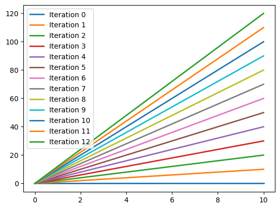

```python
plot_lines(13)
```

### A tedious solution (#1)

You can choose your color cycle by directly specifiying the colors you want:

```python
from cycler import cycler
import matplotlib as mpl
mpl.rcParams['axes.prop_cycle'] = cycler(color='bgrcmyk') # bLUE, gREEN, rED, cYAN, mAGENTA, yELLOW, BLACk
```

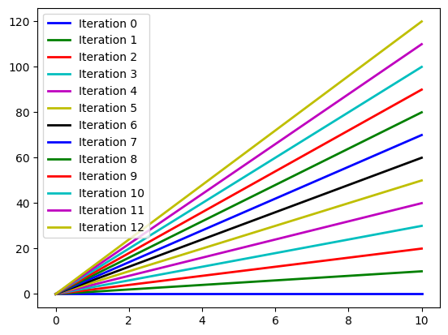

```python
plot_lines(13)
```

Or define it from a set of color names from the matplotlib list of colors:

[figure not shown]

```python
# Or a list of colors:
mpl.rcParams['axes.prop_cycle'] = cycler('color', ['blue', 'red', 'orange', 'pink', 'green', 'dodgerblue', 'darkmagenta', 'peru', 'salmon', 'purple','tomato','coral','gold','aqua'])
```

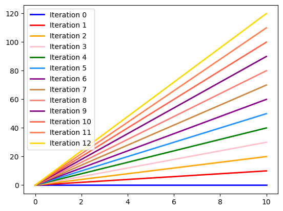

```python
plot_lines(13)
```

ok... but:

- The color selection is not optimal (some colors may look similar)
- You have to manually select them
- Depending on the problem you will need to add more colors
- They might contain colors that look the same for color-blind people

### A simple (but not optimal) solution

You can always use the matplotlib colormaps as selectors if you have many lines (or markers) to plot:

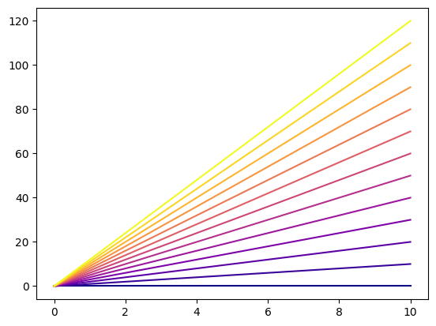

```python
cmap = mpl.colormaps['plasma']
N=13
# Take colors at regular intervals spanning the colormap.
colors = cmap(np.linspace(0, 1, N))
x = np.linspace(0,10,100)
for i in range(N):
    y = x*i + 0
    plt.plot(x,y,label='Iteration '+str(i), color=colors[i])
```

Matplotlib colormaps are numerous, some few examples:

[figure not shown]

Still...:

- Colormaps are very sequential (although other options are available)
- Still difficult for color-blind people depending on the colormap chosen
- Poor control on the exact colors and on how distinguishable are among them

# The nice solution: *distinctipy*

### What is distinctipy for?

```python
import distinctipy
```

- Pseudo-random generator of colors to maximize their color-wise distance
- Control on the type of colors
- Takes color-blindness into account (if you wish)
- Can use pastel-style colors
- Generates any number of colors you want that look inherently different

### Generate N distinct colours

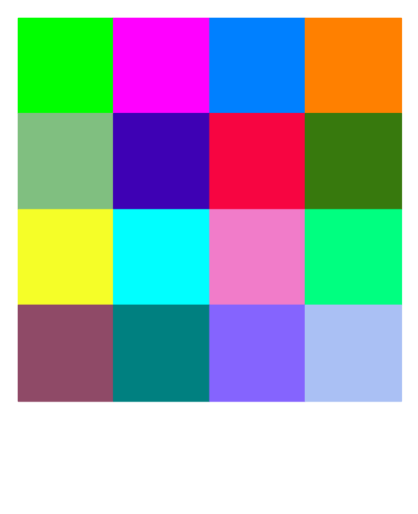

```python
# Generate 16 distinct colours (excluding black and white by default)
colors = distinctipy.get_colors(16)
# display the colours
distinctipy.color_swatch(colors)
```

**Note**: This will create a different palette each time you run it. If you wat to keep always the same remember to fix the seed using the `rng` parameter.

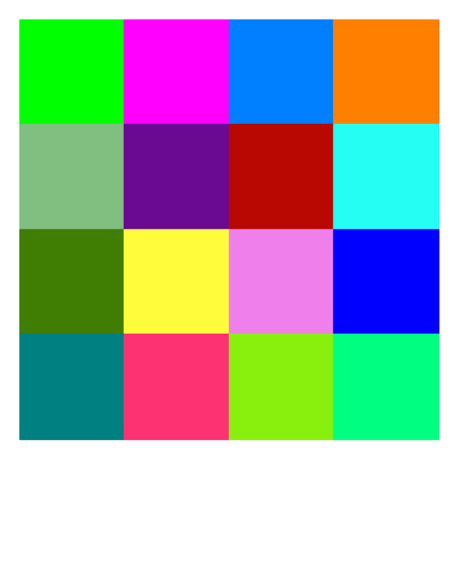

```python
# Generate 16 distinct colours (excluding black and white by default)
colors = distinctipy.get_colors(16,rng=999)
distinctipy.color_swatch(colors)
```

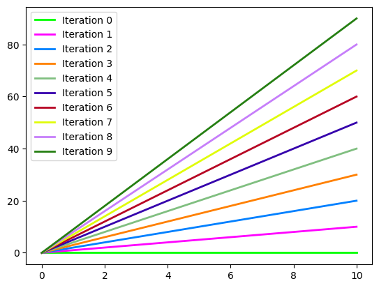

```python
# You can create as many as you need:
colors = distinctipy.get_colors(10)
plot_lines(10,colors=colors)
```

You can even add a **pastel factor** to make colors even prettier:

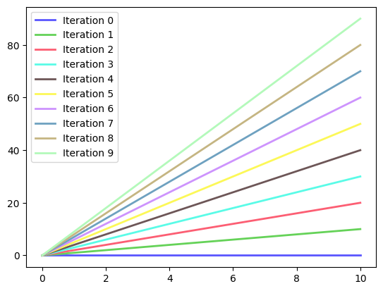

```python
# You can create as many as you need:
colors = distinctipy.get_colors(10,pastel_factor=0.5)
plot_lines(10,colors=colors)
```

### Add N additional colors

If you have already used a given set of colors (e.g.: red, gree, blue, white, black) and need to add a new color critically different from them:

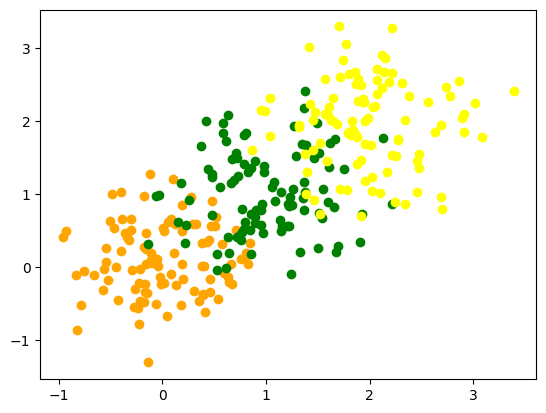

```python
input_colors = ['orange', 'green', 'yellow']
for ii,i in enumerate(input_colors):
    Npoints = 100
    for j in range(Npoints):
        x,y = np.random.normal(ii,0.5), np.random.normal(ii,0.5)
        plt.plot(x,y,'o',c=i)
```

```python
rgb_input_colors = [mpl.colors.to_rgb(i) for i in input_colors]
new_colors = distinctipy.get_colors(3, rgb_input_colors)
output_colors = rgb_input_colors+ new_colors
```

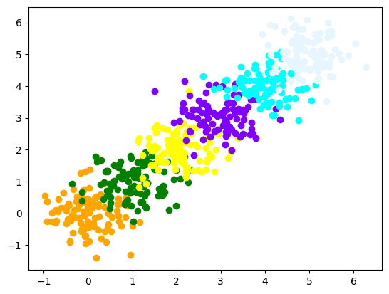

```python
for ii,i in enumerate(output_colors):
    Npoints = 100
    for j in range(Npoints):
        x,y = np.random.normal(ii,0.5), np.random.normal(ii,0.5)
        plt.plot(x,y,'o',c=i)
```

Another example: you love the **tomato** color and need 2 others to plot three Gaussians:

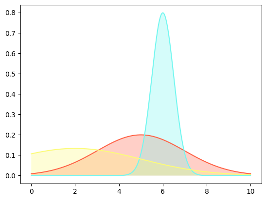

```python
input_colors = ['tomato']
rgb_input_colors = [mpl.colors.to_rgb(i) for i in input_colors]
new_colors = distinctipy.get_colors(2, rgb_input_colors,pastel_factor=0.8)
output_colors = rgb_input_colors+ new_colors
from scipy.stats import norm

x = np.linspace(0,10,1000)
for mu,sig,color in zip([5,6,2],[2,0.5,3],output_colors):
    plt.plot(x,norm.pdf(x,loc=mu,scale=sig),c=color)
    plt.fill_between(x,x*0,norm.pdf(x,loc=mu,scale=sig),facecolor=color,alpha=0.3)
```

### Text within color

You can also use `distinctipy` to choose whether to use black or white for text on top of a given color to maximize the contrast:

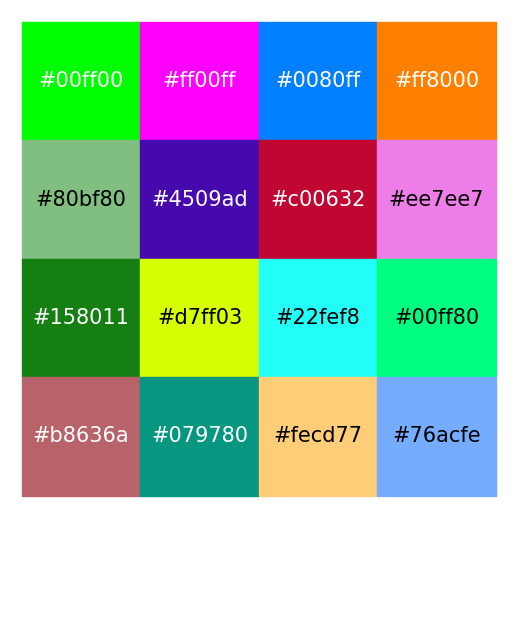

```python
# generate 16 distinct colours
colors = distinctipy.get_colors(16)

# pick black or white text for each colour
text = [distinctipy.get_text_color(color) for color in colors]

# display main colours, inverted colours and text
distinctipy.color_swatch(colors, show_text=True)
```

and generate the completely opposite color to a given color:

```python
# generate a colour as distinct as possible from each colour in colors
inverted = distinctipy.invert_colors(colors)
```

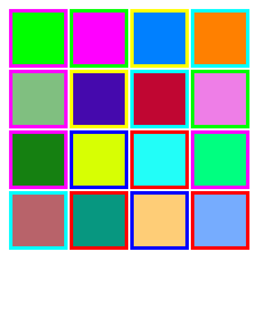

```python
distinctipy.color_swatch(colors, edgecolors=inverted)
```

### Colors for different types of **colourblindness**

There are many types of coloblindness:

- *Normal*: Normal vision
- *Protanopia*: Red-green colorblindness (1% males)
- *Protanomaly*: Red-green colorblindness (1% males, 0.01% females)
- *Deuteranopia*: Red-green colorblindness (1% males)
- *Deuteranomaly*: Red-green colorblindness (most common type: 6% males, 0.4% females)
- *Tritanopia*: Blue-yellow colourblindness (<1% males and females)
- *Tritanomaly*: Blue-yellow colourblindness (0.01% males and females)
- *Achromatopsia*: Total colourblindness
- *Achromatomaly*: Total colourblindness

What happens to color-blind people when we do not take them into account?

```
Colours distinct for normal vision:
```

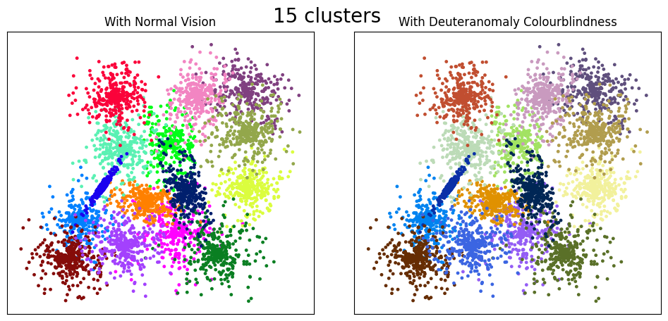

```python
from distinctipy import colorblind
from distinctipy import examples
colorblind_type = "Deuteranomaly"
dataset = "s3"

print("Colours distinct for normal vision:")
colorblind.simulate_clusters(
    dataset=dataset,
    colorblind_type=colorblind_type,
    colorblind_distinct=False
)
```

```
Colours distinct for Deuteranomaly colourblindness:
```

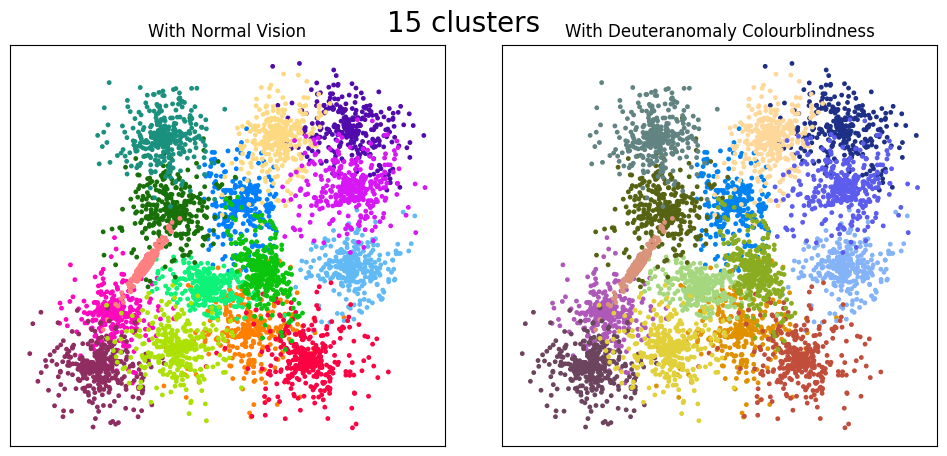

```python
print("Colours distinct for " + colorblind_type + " colourblindness:")
colorblind.simulate_clusters(
    dataset=dataset,
    colorblind_type=colorblind_type,
    colorblind_distinct=True
)
```

In practice, if you want to draw lines taking a particular type of colorblindness:

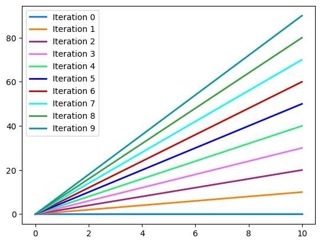

```python
colors = distinctipy.get_colors(10,colorblind_type='Deuteranomaly')
#colors = distinctipy.get_colors(10,colorblind_type='Achromatopsia')
plot_lines(10,colors=colors)
```

You can also check how a colorblind person would see your plot:

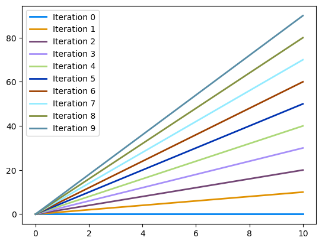

```python
with_cb = [distinctipy.colorblind.colorblind_filter(c,colorblind_type='Deuteranomaly') for c in colors]
plot_lines(10,colors=with_cb)
```

THE END!